# Influence of climate indicators on tornado ‘outbreak’ environments

Zoe Schroder

5/1/2020

Researchers project severe convective weather to increase in the future due to more frequent environmental conditions . Environmental conditions include a combination of temperature and wind driven factors. CAPE and CIN are temperature-driven factors that are inversely related and represent the ability for air to rise in the atmosphere. CAPE and CIN are projected to increase due to rising surface temperatures . BS and SRH are both wind-driven factors. BS represents the change in wind speed and direction over different depths of the atmosphere. BS is projected to decrease due to a limited temperature gradient between the equator and the poles . SRH represents the rotation within the storm and is projected to increase . Research suggests that the decrease in bulk shear will be less than the projected increase in CAPE . As a result, favorable severe weather environments are expected to be more frequent . Researchers suggest shift in environmental factors as a result of climate change, but more work is needed to quantify and explain these potential changes.

Limited research has been done to link climate change to tornado outbreak environments and associated characteristics. The studies that have been done do not match the scale of the outbreak. Researchers have analyzed climate change’s role on severe convective weather at the storm level . Climate change is a larger scale phenomenon and should be considered with large scale physical processes such as tornado outbreaks. More work is needed to quantify how outbreak-level environmental conditions are responding to climate change and influencing tornado outbreak characteristics (i.e., cluster severity, tornado counts, and casualty counts).

The goal of this research is to quantify and explain the relationship between environmental conditions and climate change. We use the term cluster instead of outbreak because we do not associate the tornadoes with the synoptic setup. The objective is to understand the role of climate change on tornado cluster environments and how that change is affecting the climatology of tornado clusters. We will fit statistical models to predict tornado cluster environments using climate change factors, including sea ice extent, El Nino Southern Oscillation Index, global temperature anomalies, and western Caribbean sea surface temperatures.

```r
load("BigDays.RData")
```

**Set the mercator projection for all figures**

```r
merc =  "+proj=merc +lon_0=0 +k=1 +x_0=0 +y_0=0 +ellps=WGS84 +datum=WGS84 +units=m +no_defs"
WGS84 <- 4326
```

Load all libraries needed for this research:

```r
library(ggplot2)
library(dplyr)
library(ggpubr)
library(sf)
library(GGally)
library(USAboundaries)
library(tmap)
library(xtable)
library(lme4)
library(gridExtra)
library(corrplot)
library(sp)
```

*Set the coordinate reference system to WGS84*

```r
st_crs(BigDays.sfdfT) <- WGS84
```

## Descriptive Statistics

*Big Days:*

```r
#The average number of tornadoes per outbreak
mean(BigDays.sfdfT$nT)
```

```
## [1] 22.3747
```

```r
#The maximum number of tornadoes per outbreak
max(BigDays.sfdfT$nT)
```

```
## [1] 173
```

```r
#What percentage of the clusters have less than the mean number of tornadoes.
x <- BigDays.sfdfT %>%
  filter(nT <= 22)
dim(x)[1]/dim(BigDays.sfdfT)[1]
```

```
## [1] 0.6819277
```

*What percentage of BigDayTornadoes are associated with each EF rating?*

```r
BigTorn = BigDayTornadoes %>%
  group_by(mag) %>%
  summarize(nT = n())

sum(BigDays.sfdfT$n0, na.rm = TRUE)/dim(BigDayTornadoes)[1] *100
```

```
## [1] 51.75812
```

```r
#52% of the BigDayTornadoes are EF0
sum(BigDays.sfdfT$n1, na.rm = TRUE)/dim(BigDayTornadoes)[1] *100
```

```
## [1] 32.59383
```

```r
#33% of the BigDayTornadoes are EF1
sum(BigDays.sfdfT$n2, na.rm = TRUE)/dim(BigDayTornadoes)[1] *100
```

```
## [1] 10.47332
```

```r
#10.5% of the BigDayTornadoes are EF2
sum(BigDays.sfdfT$n3, na.rm = TRUE)/dim(BigDayTornadoes)[1] *100
```

```
## [1] 3.387001
```

```r
#3.4% of the BigDayTornadoes are EF3
sum(BigDays.sfdfT$n4, na.rm = TRUE)/dim(BigDayTornadoes)[1] *100
```

```
## [1] 0.7538636
```

```r
#0.75% of the BigDayTornadoes are EF4
sum(BigDays.sfdfT$n5, na.rm = TRUE)/dim(BigDayTornadoes)[1] *100
```

```
## [1] 0.07538636
```

```r
#0.08% of the BigDayTornadoes are EF5
```

*what percentage of tornadoes in EF category are contained in a cluster?*

```r
AllTorn = All_Tornadoes %>%
  group_by(mag) %>%
  summarize(nT = n())

sum(BigDays.sfdfT$n0, na.rm = TRUE)/AllTorn$nT[1] *100
```

```
## [1] 48.56753
```

```r
#48.56% of all EF0s occur in a cluster
sum(BigDays.sfdfT$n1, na.rm = TRUE)/AllTorn$nT[2] *100
```

```
## [1] 62.45357
```

```r
#62% of all EF1s occur in a cluster
sum(BigDays.sfdfT$n2, na.rm = TRUE)/AllTorn$nT[3] *100
```

```
## [1] 73.53497
```

```r
#73% of all EF2s occur in a cluster
sum(BigDays.sfdfT$n3, na.rm = TRUE)/AllTorn$nT[4] *100
```

```
## [1] 86.16438
```

```r
#86% of all EF3s occur in a cluster
sum(BigDays.sfdfT$n4, na.rm = TRUE)/AllTorn$nT[5] *100
```

```
## [1] 87.5
```

```r
#87.5% of all EF4s occur in a cluster
sum(BigDays.sfdfT$n5, na.rm = TRUE)/AllTorn$nT[6] *100
```

```
## [1] 100
```

```r
#100% of all EF5s occur in a cluster
```

Clusters and NARR time

```r
BigDays.sfdfT %>%
  group_by(NARRZtime) %>%
  summarize(num = n(),
            totalTots = sum(nT))
```

[output not shown]

```
## Simple feature collection with 8 features and 3 fields
## geometry type:  GEOMETRY
## dimension:      XY
## bbox:           xmin: -116.93 ymin: 24.9879 xmax: -70.57 ymax: 49
## geographic CRS: WGS 84
## # A tibble: 8 x 4
##   NARRZtime   num totalTots                                             geometry
##   <chr>     <int>     <int>                                       <GEOMETRY [°]>
## 1 00           34       556 MULTIPOLYGON (((-90.9214 30.4023, -90.7428 30.5597,~
## 2 03            5        67 MULTIPOLYGON (((-82.8285 27.9977, -86.2387 32.296, ~
## 3 06           15       307 MULTIPOLYGON (((-95.444 28.9653, -95.4642 29.0434, ~
## 4 09            3        47 MULTIPOLYGON (((-93.8575 30.1811, -95.25679 31.5850~
## 5 12          163      3988 POLYGON ((-98.23 26.2, -98.32 26.22, -99.08 27.23, ~
## 6 15          134      3564 POLYGON ((-82.18 26.5, -82.07879 26.96003, -82.42 2~
## 7 18          258      5473 POLYGON ((-81.48 28.23, -81.5914 28.33762, -81.78 2~
## 8 21          218      4569 MULTIPOLYGON (((-89.53 29.38, -90.06598 30.10702, -~
```

```r
dim(BigDays.sfdfT %>%
  filter(nT == 10))[1]
```

```
## [1] 88
```

*Cluster tornadoes*

```r
x <- BigDays.sfdfT %>%
  filter(nT==10)
dim(x)[1]
```

```
## [1] 88
```

```r
#88 clusters have 10 tornadoes
x <- BigDays.sfdfT %>%
  filter(nT>=30)
dim(x)[1]
```

```
## [1] 166
```

```r
#166 clusters have at least 30 tornadoes
x <- BigDays.sfdfT %>%
  filter(nT>=50)
dim(x)[1]
```

```
## [1] 52
```

```r
#52 clusters have at least 50 tornadoes.
```

*Cluster casualties*

```r
x <- BigDays.sfdfT %>%
  filter(GroupDayCas==0)
dim(x)[1]
```

```
## [1] 293
```

```r
#293 clusters have 0 casualties
x <- BigDays.sfdfT %>%
  filter(GroupDayCas>=30)
dim(x)[1]
```

```
## [1] 132
```

```r
#132 clusters have at least 30 casualties
x <- BigDays.sfdfT %>%
  filter(GroupDayCas>=50)
dim(x)[1]
```

```
## [1] 90
```

```r
#90 clusters have at least 50 casualties
```

Figure: Example of clusters

```r
sts <- state.name[!state.name %in% c("Alaska", "Hawaii")]
stateBorders <- us_states(states = sts)
```

May 20, 2019 ID: 201905206481

```r
May20 <- BigDays.sfdfT %>%
  filter(cDate == "2019-05-20", groupNumber == 6481)
May20 <- st_convex_hull(May20)

May20centroid <- BigDayCentroids.df %>%
  filter(cDate == "2019-05-20", groupNumber == 6481)

May20tornadoes <- BigDayTornadoes %>%
  filter(cDate == "2019-05-20", groupNumber == May20centroid$groupNumber)

May20tornadoes <- May20tornadoes %>%
  mutate(Hour2 = ifelse(Hour <= 6, Hour + 24, Hour))
```

**Make a map of the May 20 tornado day. Obtain the state and county boundaries from the `USAboundaries` package.**

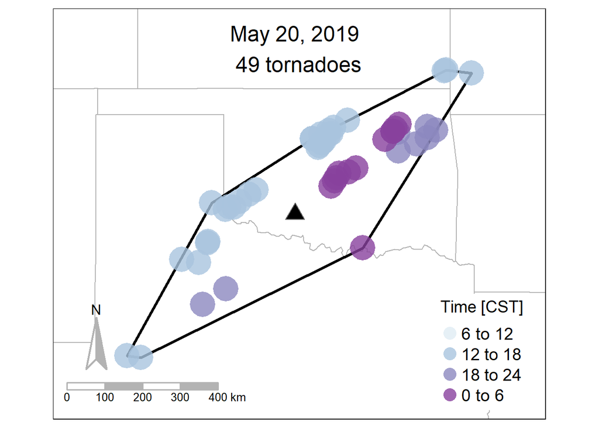

```r
May20tornadoes$Hour2 <- cut(May20tornadoes$Hour2, breaks=c(6,12,18,24,30))

May2019 <- (tm_shape(stateBorders) +
  tm_borders(col = "gray70", alpha = 1) +
  tm_compass(size = 3, fontsize = 1, lwd = 2, color.dark = "gray70") +
  tm_scale_bar(width = .3, size = 0.8, lwd = 1.75, color.dark = "gray70") +
  tm_layout(legend.bg.color = "white",
            legend.text.size = .75,
            attr.position = c("left", "bottom"),
            inner.margins = c(.15, .15, .15, .15)) +
#tm_shape(counties.sf) +
#  tm_borders(col = "gray40", alpha = .3) +
#  tm_scale_bar(width = 8, size = 8, color.dark = "gray70") +
  #tm_format("World", legend.position = c("right", "top"),
#                   attr.position = c("right", "top"),
#                   legend.frame = FALSE,
                   #title = "May 30th Tornado Group",
                   #title.size = 1.3,
                   #title.position = c("left", "TOP"),
 #                  inner.margins = c(.2, .2, .2, .2)) +
tm_shape(May20, is.master = TRUE, projection = "+proj=merc +lon_0=0 +k=1 +x_0=0 +y_0=0 +ellps=WGS84 +datum=WGS84 +units=m +no_defs") +
  tm_borders(col = "black", lwd = 3) +
tm_shape(May20tornadoes) +
  tm_symbols(size = 4, col = "Hour2", alpha = 0.8, palette = "BuPu", title.col = "Time [CST]", labels = c("6 to 12", "12 to 18", "18 to 24", "0 to 6"), border.alpha = 0) +
    tm_layout(legend.title.size = 1.1,
            legend.position = c("right", "bottom"),
            legend.stack = "horizontal",
            legend.frame = FALSE,
            legend.text.size = 1, legend.width = -0.2) +
tm_shape(May20centroid) +
  tm_symbols(size = 1.25, col = "black", shape = 24)  +
  tm_layout(title = "May 20, 2019 \n 49 tornadoes",
              title.position = c("center", "top"),
              legend.title.size = 1.4,
              legend.position = c("right", "bottom"),
              legend.stack = "horizontal",
              legend.frame = FALSE,
              legend.text.size = 1.2,
              legend.width = -0.2,
              title.size = 1.5)
)
May2019
```

Range of values for environmental variables:

```r
max(BigDays.sfdfT$maxCAPE)
```

```
## [1] 6530
```

```r
max(BigDays.sfdfT$minCIN)
```

```
## [1] 1.504114
```

```r
max(BigDays.sfdfT$maxBS_deep)
```

```
## [1] 47.9356
```

```r
max(BigDays.sfdfT$maxBS_shallow)
```

```
## [1] 35.71522
```

```r
min(BigDays.sfdfT$maxCAPE)
```

```
## [1] -0.03164387
```

```r
min(BigDays.sfdfT$minCIN)
```

```
## [1] -667.9077
```

```r
min(BigDays.sfdfT$maxBS_deep)
```

```
## [1] 5.586922
```

```r
min(BigDays.sfdfT$maxBS_shallow)
```

```
## [1] 1.084871
```

```r
mean(BigDays.sfdfT$maxCAPE)
```

```
## [1] 2198.584
```

```r
mean(BigDays.sfdfT$minCIN)
```

```
## [1] -116.3442
```

```r
mean(BigDays.sfdfT$maxBS_deep)
```

```
## [1] 27.59773
```

```r
mean(BigDays.sfdfT$maxBS_shallow)
```

```
## [1] 15.24063
```

Plot the CAPE and DLBS for the May 20, 2019 Big Day:

*First, read in the raster.*

```r
library(raster)
 rb <- brick(paste0("E:/Zoe/Projects/tornenvir_climate/merged_AWIP32.20190520/merged_AWIP32.2019052018")) #<-- this is for varying NARR times
  CAPE <- raster(rb, layer = 375)
  HLCY <- raster(rb, layer = 323)
  CIN <- raster(rb, layer = 376)
  UGRD500 <- raster(rb, layer = 117)
  VGRD500 <- raster(rb, layer = 118)
  UGRD850 <- raster(rb, layer = 206)
  VGRD850 <- raster(rb, layer = 207)
  UGRDsfc <- raster(rb, layer = 293)
  VGRDsfc <- raster(rb, layer = 294)
  DLBS <- sqrt(((UGRD500 - UGRDsfc)**2) + ((VGRD500 - VGRDsfc)**2))
  SLBS <- sqrt(((UGRD850 - UGRDsfc)**2) + ((VGRD850 - VGRDsfc)**2))
```

**Convective Available Potential energy**

```r
#CAPE = projectRaster(CAPE, crs = "+proj=lcc +lat_1=50 +lat_2=50 +lat_0=50 +lon_0=-107 +x_0=0 +y_0=0 +a=6371200 +b=6371200 +units=m +no_defs")
May20 <- st_transform(May20,
  crs = "+proj=lcc +lat_1=50 +lat_2=50 +lat_0=50 +lon_0=-107 +x_0=0 +y_0=0 +a=6371200 +b=6371200 +units=m +no_defs")
```

```r
CAPE_May20 <- crop(CAPE, extent(May20))
CAPE_extent<- mask(CAPE_May20, May20)
```

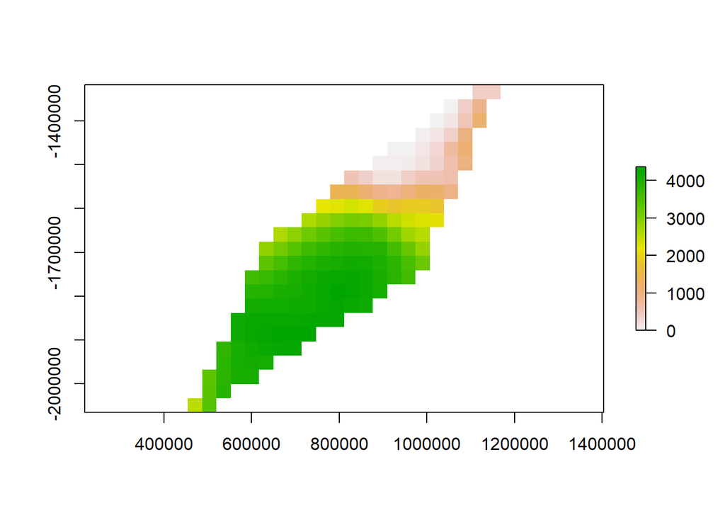

```r
plot(CAPE_extent)
```

```r
maxCAPE <- which.max(CAPE_extent) #Returns a pixel number

#Test that this max value equals the one in BigDays.sfdfT
test <- getValues(CAPE_extent)
test<-as.matrix(test, ncol=1)
```

```r
CAPEmaxpos <- xyFromCell(CAPE_extent, maxCAPE)

xy <- data.frame(CAPEmaxpos)
CAPE_latlon <- data.frame(lon=xy$x, lat=xy$y)
print(CAPE_latlon)
```

```
##        lon      lat
## 1 795031.8 -1788265
## 2 665179.8 -1885654
## 3 730105.8 -1885654
```

```r
CAPE_latlon <- SpatialPoints(CAPE_latlon)
proj4string(CAPE_latlon) = CRS("+proj=lcc +lat_1=50 +lat_2=50 +lat_0=50 +lon_0=-107 +x_0=0 +y_0=0 +a=6371200 +b=6371200 +units=m +no_defs")
counties <- us_counties()
states <- us_states()
```

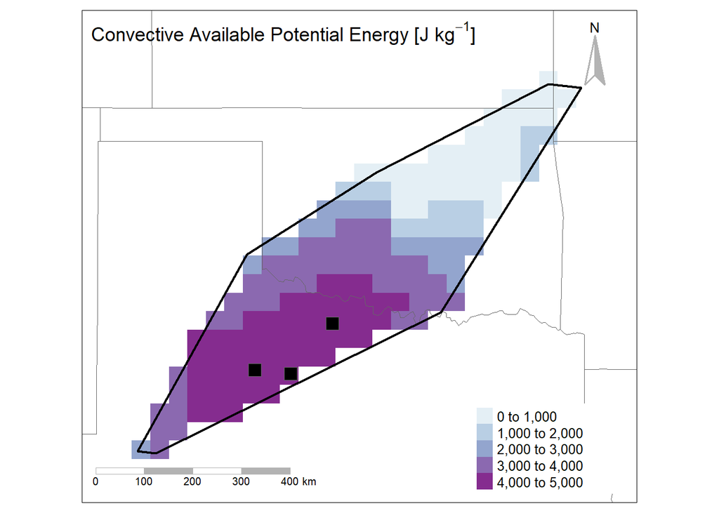

```r
p1 <- tm_shape(CAPE_extent) +
  tm_raster(title = "",  n = 6, palette = "BuPu") +
  tm_format(title = expression(paste("Convective Available Potential Energy [J ",kg^-1,"]")), "World", legend.position = c("right", "bottom"),
                   attr.position = c("right", "top"),
                   legend.frame = FALSE,
                   inner.margins = c(.1, 0.1, .15, .1), #bottom, left, top
                    legend.text.size = 1, legend.width = -0.28, legend.title.size=1, legend.bg.color = "white", title.size = 1.4) +
#tm_shape(counties) +
  #tm_borders(col = "grey") +
  tm_scale_bar(width = 0.3, size = 0.8, position = c("left", "bottom"), color.dark = "gray70") +
  tm_compass(size = 3, fontsize = 1, lwd = 2, color.dark = "gray70") +
tm_shape(states) +
  tm_borders() +
tm_shape(May20, is.master = TRUE, projection = merc) +
  tm_borders(col = "black", lwd = 3)  +
#tm_shape(May6centroid) +
#  tm_symbols(size = 1.25, col = "black", shape = 24) +
tm_shape(CAPE_latlon) +
  tm_symbols(size = 1.4, col = "black", shape = 22)
p1
```

**Bulk Shear**

```r
BS_May20 <- crop(DLBS, extent(May20))
BS_extent<- mask(BS_May20, May20)
```

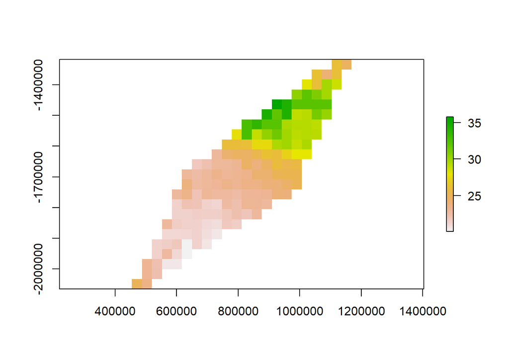

```r
plot(BS_extent)
```

```r
maxBS <- which.max(BS_extent)
```

```r
BSmaxpos <- xyFromCell(BS_extent, maxBS)

xy <- data.frame(BSmaxpos)
BS_latlon <- data.frame(lon=xy$x, lat=xy$y)
print(BS_latlon)
```

```
##        lon      lat
## 1 924883.8 -1463635
```

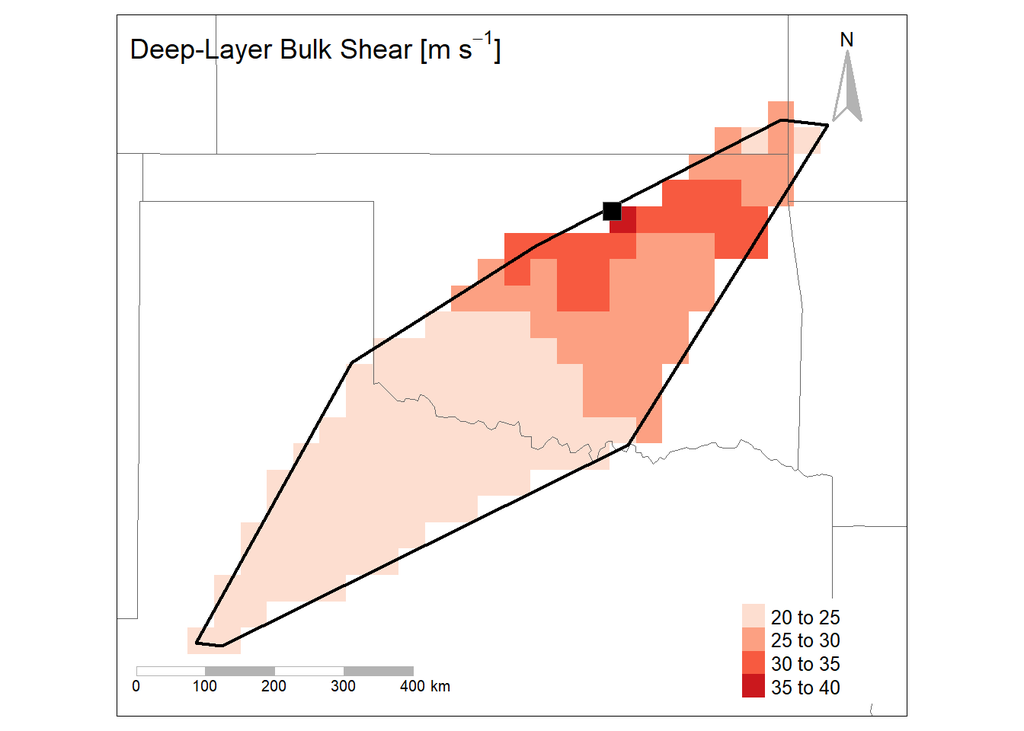

```r
BS_latlon <- SpatialPoints(BS_latlon)
proj4string(BS_latlon) = CRS("+proj=lcc +lat_1=50 +lat_2=50 +lat_0=50 +lon_0=-107 +x_0=0 +y_0=0 +a=6371200 +b=6371200 +units=m +no_defs")
p4 <- tm_shape(BS_extent) +
  tm_raster(title = "", n = 5, palette = "Reds") +
  tm_format(title = expression(paste("Deep-Layer Bulk Shear [m ",s^-1,"]")), "World", legend.position = c("right", "bottom"),
  #tm_format(title = expression(paste("Deep-Layer Bulk Shear [m ", s^-1, "]")), "World", legend.position = c("right", "bottom"),
                   attr.position = c("right", "top"),
                   legend.frame = FALSE,
                   inner.margins = c(.1, 0.1, .15, .1), #bottom, left, top
                    legend.text.size = 1, legend.width = -0.2, legend.title.size=1, legend.bg.color = "white", title.size = 1.4) +
#tm_shape(counties) +
#  tm_borders(col = "grey") +
  tm_scale_bar(width = 0.3, size = 0.8, position = c("left", "bottom"), color.dark = "gray70") +
  tm_compass(size = 3, fontsize = 1, lwd = 2, color.dark = "gray70") +
tm_shape(states) +
  tm_borders() +
tm_shape(May20, is.master = TRUE, projection = merc) +
  tm_borders(col = "black", lwd = 3)  +
#tm_shape(May6centroid) +
#  tm_symbols(size = 1.25, col = "black", shape = 24) +
tm_shape(BS_latlon) +
  tm_symbols(size = 1.4, col = "black", shape = 22)
p4
```

**Combine into one figure:**

```r
tmap_arrange(p1, p4, ncol = 2, nrow = 1)
```

```
## Some legend labels were too wide. These labels have been resized to 0.55, 0.55, 0.55, 0.55. Increase legend.width (argument of tm_layout) to make the legend wider and therefore the labels larger.
```

```
## Legend labels were too wide. The labels have been resized to 0.54, 0.54, 0.54, 0.54. Increase legend.width (argument of tm_layout) to make the legend wider and therefore the labels larger.
```

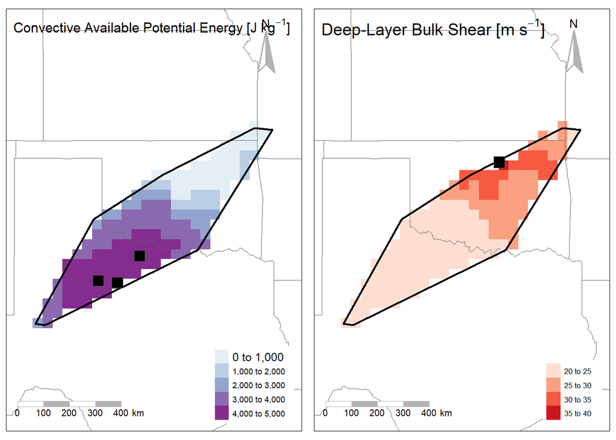

# Climate variables.

Range of Climate Values

```r
max(BigDays.sfdfT$max_CSST)
```

```
## [1] 32.5
```

```r
max(BigDays.sfdfT$max_GAKSST)
```

```
## [1] 18.42
```

```r
max(BigDays.sfdfT$max_Nino34)
```

```
## [1] 32.3
```

```r
max(BigDays.sfdfT$NAO_daily)
```

```
## [1] 3.263
```

```r
max(BigDays.sfdfT$PNA_daily)
```

```
## [1] 3.7118
```

```r
max(BigDays.sfdfT$MJO_daily)
```

```
## [1] 3.6035
```

```r
min(BigDays.sfdfT$max_CSST)
```

```
## [1] 26.69
```

```r
min(BigDays.sfdfT$max_GAKSST)
```

```
## [1] 5.82
```

```r
min(BigDays.sfdfT$max_Nino34)
```

```
## [1] 27.48
```

```r
min(BigDays.sfdfT$NAO_daily)
```

```
## [1] -3.6146
```

```r
min(BigDays.sfdfT$PNA_daily)
```

```
## [1] -6.2192
```

```r
min(BigDays.sfdfT$MJO_daily)
```

```
## [1] 0.047
```

```r
mean(BigDays.sfdfT$max_CSST)
```

```
## [1] 29.67566
```

```r
mean(BigDays.sfdfT$max_GAKSST)
```

```
## [1] 10.46359
```

```r
mean(BigDays.sfdfT$max_Nino34)
```

```
## [1] 29.58283
```

```r
mean(BigDays.sfdfT$NAO_daily)
```

```
## [1] -0.01968012
```

```r
mean(BigDays.sfdfT$PNA_daily)
```

```
## [1] -0.5689327
```

```r
mean(BigDays.sfdfT$MJO_daily)
```

```
## [1] 1.306776
```

CSST and GAKSST

[figure not shown]

```r
CSST_xcoord <- c(-90, -70, -70, -90)
CSST_ycoord <- c(15, 15, 25, 25)
xym <- cbind(CSST_xcoord, CSST_ycoord)

p = Polygon(xym)
ps = Polygons(list(p),1)
CSST_sp = SpatialPolygons(list(ps))
plot(CSST_sp)
```

[figure not shown]

```r
GAKSST_xcoord <- c(-157.5,-133.1,-133.1,-157.5)
GAKSST_ycoord <- c(50.5, 50.5, 60, 60)
xym <- cbind(GAKSST_xcoord, GAKSST_ycoord)

p = Polygon(xym)
ps = Polygons(list(p),1)
GAKSST_sp = SpatialPolygons(list(ps))
plot(GAKSST_sp)
```

[figure not shown]

```r
NINO_xcoord <- c(-170, -120, -120, -170)
NINO_ycoord <- c(-5, -5, 5, 5)
xym <- cbind(NINO_xcoord, NINO_ycoord)

p = Polygon(xym)
ps = Polygons(list(p),1)
NINO_sp = SpatialPolygons(list(ps))
plot(NINO_sp)
```

[figure not shown]

```r
MyBorders_x <- c(-180, -60, -60, -180)
MyBorders_y <- c(-10, -10, 70, 70)
xym <- cbind(MyBorders_x, MyBorders_y)

p = Polygon(xym)
ps = Polygons(list(p),1)
MyBorders_sp = SpatialPolygons(list(ps))
plot(MyBorders_sp)
```

```r
data("World")

West_Hemisphere <- World %>%
  filter(continent %in% c("North America", "South America"))

SSTmap <- tm_shape(World, projection = "+proj=merc +lon_0=0 +k=1 +x_0=0 +y_0=0 +ellps=WGS84 +datum=WGS84 +units=m +no_defs") +
  tm_polygons(col = "gray70", alpha = 1) +
 tm_shape(MyBorders_sp, is.master = TRUE, projection = "+proj=merc +lon_0=0 +k=1 +x_0=0 +y_0=0 +ellps=WGS84 +datum=WGS84 +units=m +no_defs") +
  tm_polygons(alpha = 0, border.alpha = 0)+
tm_shape(CSST_sp, projection = "+proj=merc +lon_0=0 +k=1 +x_0=0 +y_0=0 +ellps=WGS84 +datum=WGS84 +units=m +no_defs") +
  tm_polygons(col = "blue", alpha = 0.6)+
tm_shape(GAKSST_sp, projection = "+proj=merc +lon_0=0 +k=1 +x_0=0 +y_0=0 +ellps=WGS84 +datum=WGS84 +units=m +no_defs") +
  tm_polygons(col = "darkgreen", alpha = 0.6, legend.show = TRUE)+
tm_shape(NINO_sp, projection = "+proj=merc +lon_0=0 +k=1 +x_0=0 +y_0=0 +ellps=WGS84 +datum=WGS84 +units=m +no_defs") +
  tm_polygons(col = "goldenrod2", alpha = 0.6, legend.show = TRUE) +
tm_shape(stateBorders) +
  tm_borders(col = "gray40", alpha = 1) +
  tm_compass(size = 2, fontsize = 1, lwd = 2, color.dark = "gray70") +
  tm_scale_bar(width = .3, size = 0.8, lwd = 1.75, color.dark = "gray70") +
  tm_add_legend(type = "symbol", labels = c("Caribbean SST Zone", "Gulf of Alaska SST Zone", "Nino 3.4 SST Zone"), col = c("blue", "darkgreen", "goldenrod2"), size = 2, shape = 22, alpha = 0.6) +
  tm_layout(title = "Sea Surface Temperatures",
            title.bg.color = "white",
            title.size = 1.2,
            legend.bg.color = "white",
            legend.text.size = .8,
            attr.position = c("left", "bottom"),
            legend.position = c("right", "bottom"),
            legend.stack = "horizontal",
            inner.margins = c(0.3,0.05,0.05,0))
SSTmap
```

```
## Legend labels were too wide. The labels have been resized to 0.62, 0.52, 0.67. Increase legend.width (argument of tm_layout) to make the legend wider and therefore the labels larger.
```

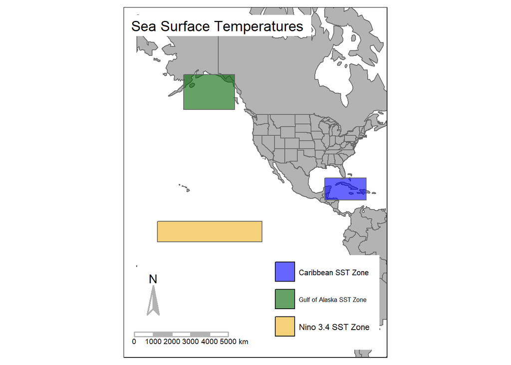

NAO locations:

```r
NAO_xcoord <- c(-70, -10, -10, -70)
NAO_ycoord <- c(55, 55, 70, 70)
xym <- cbind(NAO_xcoord, NAO_ycoord)

p = Polygon(xym)
ps = Polygons(list(p),1)
NAO_sp = SpatialPolygons(list(ps))
plot(NAO_sp)
```

[figure not shown]

```r
NAO2_xcoord <- c(-70,-10,-10,-70)
NAO2_ycoord <- c(35, 35, 45, 45)
xym <- cbind(NAO2_xcoord, NAO2_ycoord)

p = Polygon(xym)
ps = Polygons(list(p),1)
NAO2_sp = SpatialPolygons(list(ps))
plot(NAO2_sp)
```

[figure not shown]

```r
MyBorders_x <- c(-80, -5, -5, -80)
MyBorders_y <- c(30, 30, 75, 75)
xym <- cbind(MyBorders_x, MyBorders_y)

p = Polygon(xym)
ps = Polygons(list(p),1)
MyBorders_sp = SpatialPolygons(list(ps))
plot(MyBorders_sp)
```

```r
data("World")

West_Hemisphere <- World %>%
  filter(continent %in% c("North America", "South America"))

NAOmap <- tm_shape(World, projection = "+proj=merc +lon_0=0 +k=1 +x_0=0 +y_0=0 +ellps=WGS84 +datum=WGS84 +units=m +no_defs") +
  tm_polygons(col = "gray70", alpha = 1) +
 tm_shape(MyBorders_sp, is.master = TRUE, projection = "+proj=merc +lon_0=0 +k=1 +x_0=0 +y_0=0 +ellps=WGS84 +datum=WGS84 +units=m +no_defs") +
  tm_polygons(alpha = 0, border.alpha = 0)+
tm_shape(NAO_sp, projection = "+proj=merc +lon_0=0 +k=1 +x_0=0 +y_0=0 +ellps=WGS84 +datum=WGS84 +units=m +no_defs") +
  tm_polygons(col = "blue", alpha = 0.6)+
tm_shape(NAO2_sp, projection = "+proj=merc +lon_0=0 +k=1 +x_0=0 +y_0=0 +ellps=WGS84 +datum=WGS84 +units=m +no_defs") +
  tm_polygons(col = "darkgreen", alpha = 0.6, legend.show = TRUE)+
tm_shape(stateBorders) +
  tm_borders(col = "gray40", alpha = 1) +
  tm_compass(size = 2, fontsize = 1, lwd = 2, color.dark = "gray70", bg.color = "white") +
  tm_scale_bar(width = .35, size = 0.8, lwd = 1.9, color.dark = "gray70", bg.color = "white") +
  tm_add_legend(type = "symbol", labels = c("Icelandic Low", "Azores High"), col = c("blue", "darkgreen"), size = 2, shape = 22, alpha = 0.6) +
  tm_layout(title = "North Atlantic Oscillation",
            title.size = 1.2,
            title.bg.color = "white",
            legend.bg.color = "white",
            legend.text.size = .8,
            attr.position = c("right", "bottom"),
            legend.position = c("left", "bottom"),
            legend.stack = "horizontal",
            inner.margins = c(0.25,0.05,0.05,0))
```

PNA Locations:

```r
PNA_xcoord <- c(-180, -140, -140, -180)
PNA_ycoord <- c(15, 15, 25, 25)
xym <- cbind(PNA_xcoord, PNA_ycoord)

p = Polygon(xym)
ps = Polygons(list(p),1)
PNA_sp = SpatialPolygons(list(ps))
plot(PNA_sp)
```

```r
PNA2_xcoord <- c(-180, -140, -140, -180)
PNA2_ycoord <- c(40, 40, 50, 50)
xym <- cbind(PNA2_xcoord, PNA2_ycoord)

p = Polygon(xym)
ps = Polygons(list(p),1)
PNA2_sp = SpatialPolygons(list(ps))
plot(PNA2_sp)
```

[figure not shown]

```r
PNA3_xcoord <- c(-90, -70, -70, -90)
PNA3_ycoord <- c(25, 25, 35, 35)
xym <- cbind(PNA3_xcoord, PNA3_ycoord)

p = Polygon(xym)
ps = Polygons(list(p),1)
PNA3_sp = SpatialPolygons(list(ps))
plot(PNA3_sp)
```

[figure not shown]

```r
PNA4_xcoord <- c(-125, -105, -105, -125)
PNA4_ycoord <- c(45, 45, 60, 60)
xym <- cbind(PNA4_xcoord, PNA4_ycoord)

p = Polygon(xym)
ps = Polygons(list(p),1)
PNA4_sp = SpatialPolygons(list(ps))
plot(PNA4_sp)
```

[figure not shown]

```r
MyBorders_x <- c(-180, -65, -65, -180)
MyBorders_y <- c(10, 10, 65, 65)
xym <- cbind(MyBorders_x, MyBorders_y)

p = Polygon(xym)
ps = Polygons(list(p),1)
MyBorders_sp = SpatialPolygons(list(ps))
plot(MyBorders_sp)
```

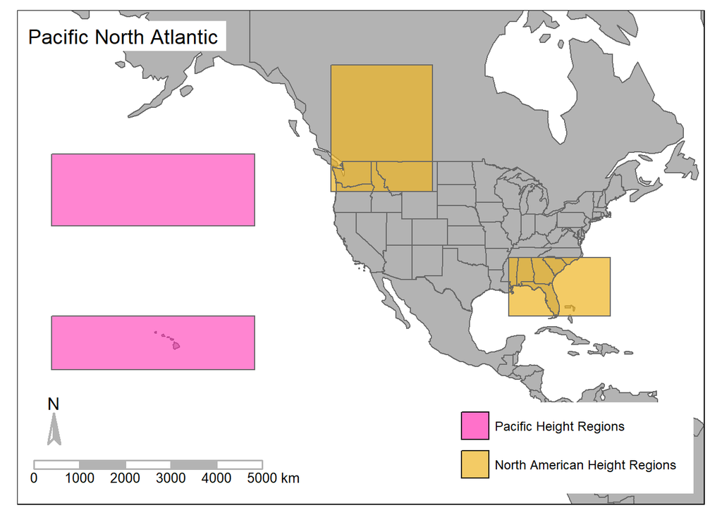

```r
data("World")

West_Hemisphere <- World %>%
  filter(continent %in% c("North America", "South America"))

PNAmap <- tm_shape(World, projection = "+proj=merc +lon_0=0 +k=1 +x_0=0 +y_0=0 +ellps=WGS84 +datum=WGS84 +units=m +no_defs") +
  tm_polygons(col = "gray70", alpha = 1) +
 tm_shape(MyBorders_sp, is.master = TRUE, projection = "+proj=merc +lon_0=0 +k=1 +x_0=0 +y_0=0 +ellps=WGS84 +datum=WGS84 +units=m +no_defs") +
  tm_polygons(alpha = 0, border.alpha = 0)+
tm_shape(PNA_sp, projection = "+proj=merc +lon_0=0 +k=1 +x_0=0 +y_0=0 +ellps=WGS84 +datum=WGS84 +units=m +no_defs") +
  tm_polygons(col = "maroon1", alpha = 0.6)+
tm_shape(PNA2_sp, projection = "+proj=merc +lon_0=0 +k=1 +x_0=0 +y_0=0 +ellps=WGS84 +datum=WGS84 +units=m +no_defs") +
  tm_polygons(col = "maroon1", alpha = 0.6, legend.show = TRUE)+
tm_shape(PNA3_sp, projection = "+proj=merc +lon_0=0 +k=1 +x_0=0 +y_0=0 +ellps=WGS84 +datum=WGS84 +units=m +no_defs") +
  tm_polygons(col = "goldenrod2", alpha = 0.7, legend.show = TRUE)+
  tm_shape(PNA4_sp, projection = "+proj=merc +lon_0=0 +k=1 +x_0=0 +y_0=0 +ellps=WGS84 +datum=WGS84 +units=m +no_defs") +
  tm_polygons(col = "goldenrod2", alpha = 0.7, legend.show = TRUE)+
tm_shape(stateBorders) +
  tm_borders(col = "gray40", alpha = 1) +
  tm_compass(size = 1.5, fontsize = 1, lwd = 2, color.dark = "gray70") +
  tm_scale_bar(width = .3, size = 0.8, lwd = 1.75, color.dark = "gray70") +
  tm_add_legend(type = "symbol", labels = c("Pacific Height Regions", "North American Height Regions"), col = c("maroon1", "goldenrod2"), size = 2, shape = 22, alpha = 0.7) +
  tm_layout(title = "Pacific North Atlantic",
            title.size = 1.2,
            title.bg.color = "white",
            legend.width = 0.8,
            legend.bg.color = "white",
            legend.text.size = .75,
            attr.position = c("left", "bottom"),
            legend.position = c("right", "bottom"),
            legend.stack = "horizontal",
            inner.margins = c(0.220,0.05,0,0.1))
PNAmap
```

```r
tmap_arrange(SSTmap, NAOmap, PNAmap, ncol = 2)
```

```
## Legend labels were too wide. The labels have been resized to 0.55, 0.47, 0.60. Increase legend.width (argument of tm_layout) to make the legend wider and therefore the labels larger.
```

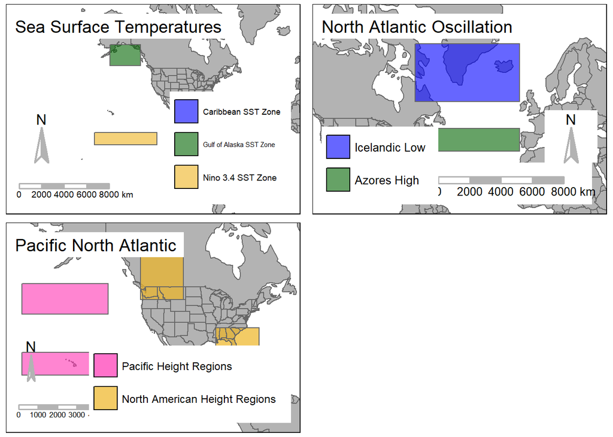

```r
#% DLBS < mean
(dim(BigDays.sfdfT %>% filter(maxBS_deep <= mean(maxBS_deep)))[1] / dim(BigDays.sfdfT)[1]) *100
```

```
## [1] 50.12048
```

```r
#%SLBS < mean
(dim(BigDays.sfdfT %>% filter(maxBS_shallow <= mean(maxBS_shallow)))[1] / dim(BigDays.sfdfT)[1]) *100
```

```
## [1] 51.80723
```

```r
#% CAPE < mean
(dim(BigDays.sfdfT %>% filter(maxCAPE <= mean(maxCAPE)))[1] / dim(BigDays.sfdfT)[1]) *100
```

```
## [1] 53.9759
```

Distributions of the response variables:

`CAPE`

```r
plot_CAPE <- ggplot(BigDays.sfdfT, aes(maxCAPE)) +
  geom_histogram(boundary = 50,
                 bins = 43,
                 alpha = 0.9,
                 color = "white",
                 fill = "Grey40",
                 size = 0.1) +
  scale_x_continuous(expand = c(0,0), limits = c(0,7000)) +
  #scale_x_log10() +
  xlab(expression(paste("Maximum CAPE [J ", kg^-1, "]"))) +
  scale_y_continuous(expand = c(0,0), breaks = c(0, 10,20,30,40,50), labels = c("0", "10", "20", "30", "40", "50"), limits = c(0, 50)) +
  ylab("Number of Clusters") +
  ggtitle("c") +
  theme_bw() +
  theme(text = element_text(size=12), plot.background = element_rect(color = "grey40"), panel.border = element_rect(color = "white"), plot.margin=unit(c(0.5, 0.5, 0.5, 0.5),"cm"))
```

`Deep Layer Shear`

```r
plot_DLBS <- ggplot(BigDays.sfdfT, aes(maxBS_deep)) +
  geom_histogram(boundary = 50,
                 bins = 43,
                 alpha = 0.9,
                 color = "white",
                 fill = "Grey40",
                 size = 0.1) +
  scale_x_continuous(expand = c(0,0), limits = c(0,50)) +
  #scale_x_log10() +
  xlab(expression(paste("Maximum Deep Layer Bulk Shear [m ", s^-1, "]"))) +
  scale_y_continuous(expand = c(0,0), breaks = c(0, 10,20,30,40,50, 60), labels = c("0", "10", "20", "30", "40", "50", "60"), limits = c(0, 60)) +
  ylab("Number of Clusters") +
  ggtitle("a") +
  theme_bw() +
  theme(text = element_text(size=12), plot.background = element_rect(color = "grey40"), panel.border = element_rect(color = "white"), plot.margin=unit(c(0.5, 0.5, 0.5, 0.5),"cm"))
```

`Shallow Layer Shear`

```r
plot_SLBS <- ggplot(BigDays.sfdfT, aes(maxBS_shallow)) +
  geom_histogram(boundary = 50,
                 bins = 43,
                 alpha = 0.9,
                 color = "white",
                 fill = "Grey40",
                 size = 0.1) +
  scale_x_continuous(expand = c(0,0), limits = c(0,40)) +
  #scale_x_log10() +
  xlab(expression(paste("Maximum Shallow Layer Bulk Shear [m ", s^-1, "]"))) +
  scale_y_continuous(expand = c(0,0), breaks = c(0, 10,20,30,40,50), labels = c("0", "10", "20", "30", "40", "50"), limits = c(0, 50)) +
  ylab("Number of Clusters") +
  ggtitle("b") +
  theme_bw() +
  theme(text = element_text(size=12), plot.background = element_rect(color = "grey40"), panel.border = element_rect(color = "white"), plot.margin=unit(c(0.5, 0.5, 0.5, 0.5),"cm"))
```

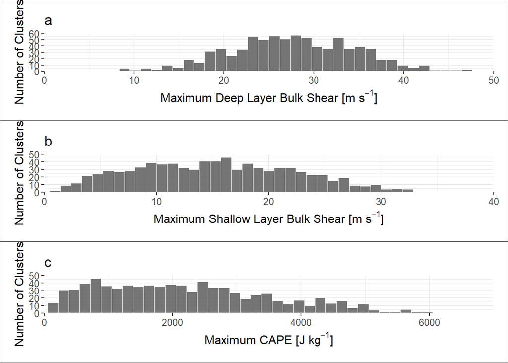

```r
ggarrange(plot_DLBS, plot_SLBS, plot_CAPE, ncol = 1, nrow = 3)
```

Does collinearity exist between the explanatory variables?:

*What is the correlation between the climate variables?*

```r
ClimVars <- data.frame( CSST = BigDays.sfdfT$max_CSST10day, GAKSST = BigDays.sfdfT$max_GAKSST10day, ENSO = BigDays.sfdfT$avg_Nino3410day, NAO = BigDays.sfdfT$NAO_10day, PNA = BigDays.sfdfT$PNA_10day, MJO = BigDays.sfdfT$MJO_10day)
```

*Create a figure to show correlations between the climate variables.*

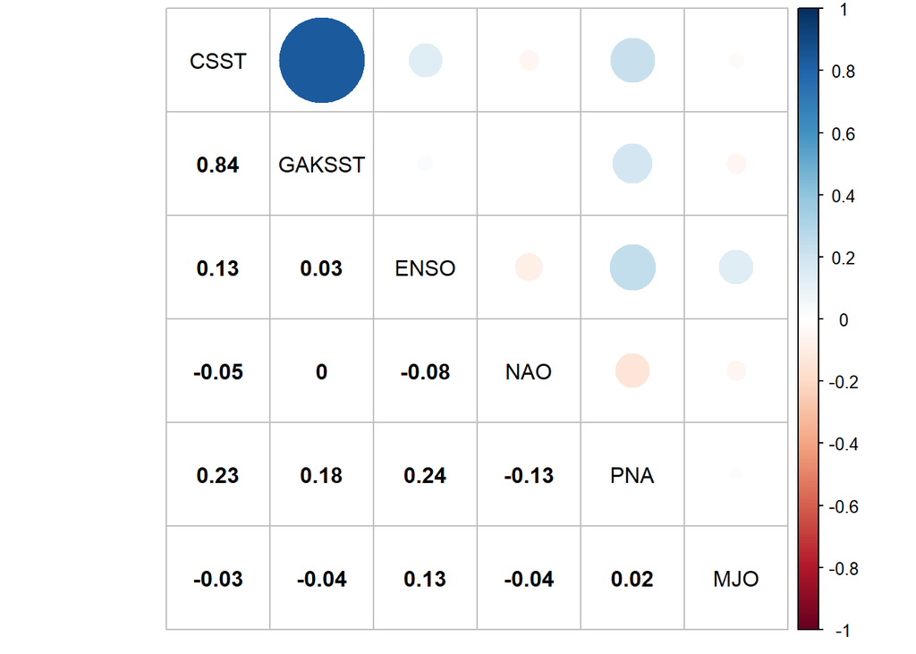

```r
corrplot.mixed(cor(ClimVars), tl.col="black", lower.col="black", number.cex = 1, tl.cex = 1)
```

*There is a strong correlation between Caribbean sea surface temperature (ATL_SST) and Gulf of Alaska sea surface temperatures (GAK_SST). Therefore, we need to account for this. We do this by creating a new variable that is the gradient between ATL_SST and GAK_SST.*

```r
BigDays.sfdfT <- BigDays.sfdfT %>%
  mutate(SSTgradient_10day = max_CSST10day - max_GAKSST10day,
         SSTgradient_15day = max_CSST15day - max_GAKSST15day,
         SSTgradient_20day = max_CSST20day - max_GAKSST20day,
         SSTgradient_30day = max_CSST30day - max_GAKSST30day,
         SSTgradient_5day = max_CSST5day - max_GAKSST5day)
```

What are the values of the climate variables?

```r
max(BigDays.sfdfT$max_Nino3415day)
```

```
## [1] 31.54437
```

```r
min(BigDays.sfdfT$max_Nino3415day)
```

```
## [1] 27.62
```

```r
mean(BigDays.sfdfT$max_Nino3415day)
```

```
## [1] 29.57924
```

```r
max(BigDays.sfdfT$NAO_15day)
```

```
## [1] 2.651894
```

```r
min(BigDays.sfdfT$NAO_15day)
```

```
## [1] -2.945781
```

```r
mean(BigDays.sfdfT$NAO_15day)
```

```
## [1] -0.02255319
```

```r
max(BigDays.sfdfT$PNA_15day)
```

```
## [1] 3.667137
```

```r
min(BigDays.sfdfT$PNA_15day)
```

```
## [1] -4.65045
```

```r
mean(BigDays.sfdfT$PNA_15day)
```

```
## [1] -0.2096645
```

```r
max(BigDays.sfdfT$MJO_15day)
```

```
## [1] 3.202257
```

```r
min(BigDays.sfdfT$MJO_15day)
```

```
## [1] 0.2676739
```

```r
mean(BigDays.sfdfT$MJO_15day)
```

```
## [1] 1.297169
```

```r
max(BigDays.sfdfT$SSTgradient_15day)
```

```
## [1] 22.38187
```

```r
min(BigDays.sfdfT$SSTgradient_15day)
```

```
## [1] 12.195
```

```r
mean(BigDays.sfdfT$SSTgradient_15day)
```

```
## [1] 19.2854
```

*Now let’s look at the correlation matrix again:*

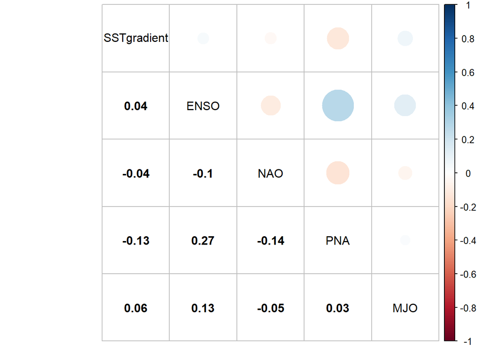

```r
ClimVars2 <- data.frame(SSTgradient = BigDays.sfdfT$SSTgradient_15day, ENSO = BigDays.sfdfT$avg_Nino3415day, NAO = BigDays.sfdfT$NAO_15day, PNA = BigDays.sfdfT$PNA_15day, MJO = BigDays.sfdfT$MJO_15day)

corrplot.mixed(cor(ClimVars2), tl.col="black", lower.col="black", number.cex = 1, tl.cex = 1)
```

All collinearity issues have been removed.

##DLBS Model:

Bivariate Relationship:

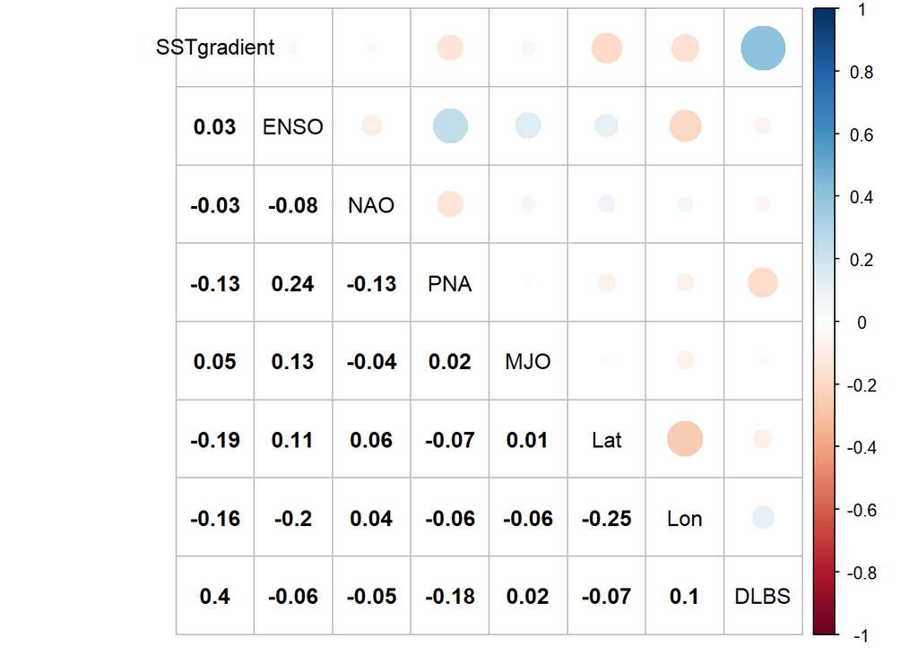

```r
DLBS_env <- data.frame(SSTgradient = BigDays.sfdfT$SSTgradient_10day, ENSO = BigDays.sfdfT$avg_Nino3410day, NAO = BigDays.sfdfT$NAO_10day, PNA = BigDays.sfdfT$PNA_10day, MJO = BigDays.sfdfT$MJO_10day, Lat = BigDays.sfdfT$Lat, Lon = BigDays.sfdfT$Lon, DLBS = BigDays.sfdfT$maxBS_deep)


corrplot.mixed(cor(DLBS_env), tl.col="black", lower.col="black", number.cex = 1, tl.cex = 1)
```

Initial Model:

```r
DLBS_m1 <- lm(maxBS_deep ~ SSTgradient_15day + avg_Nino3415day + NAO_15day + PNA_15day +  MJO_15day + Lat + Lon + Year, data = BigDays.sfdfT)
summary(DLBS_m1)
```

```
##
## Call:
## lm(formula = maxBS_deep ~ SSTgradient_15day + avg_Nino3415day +
##     NAO_15day + PNA_15day + MJO_15day + Lat + Lon + Year, data = BigDays.sfdfT)
##
## Residuals:
##      Min       1Q   Median       3Q      Max
## -22.9407  -4.1140  -0.1028   4.0678  18.2358
##
## Coefficients:
##                     Estimate Std. Error t value Pr(>|t|)
## (Intercept)       -1.192e+02  5.960e+01  -2.000  0.04585 *
## SSTgradient_15day  1.489e+00  1.179e-01  12.631  < 2e-16 ***
## avg_Nino3415day   -3.501e-01  2.826e-01  -1.239  0.21579
## NAO_15day         -8.467e-01  2.880e-01  -2.940  0.00338 **
## PNA_15day         -7.226e-01  2.200e-01  -3.284  0.00107 **
## MJO_15day          8.504e-03  4.267e-01   0.020  0.98410
## Lat                8.229e-02  5.562e-02   1.480  0.13936
## Lon                1.809e-01  3.586e-02   5.044 5.62e-07 ***
## Year               7.028e-02  3.010e-02   2.334  0.01982 *
## ---
## Signif. codes:  0 '***' 0.001 '**' 0.01 '*' 0.05 '.' 0.1 ' ' 1
##
## Residual standard error: 6.388 on 821 degrees of freedom
## Multiple R-squared:  0.2111, Adjusted R-squared:  0.2034
## F-statistic: 27.45 on 8 and 821 DF,  p-value: < 2.2e-16
```

Seasonal Trend:

```r
DLBSByMonth <- BigDays.sfdfT %>%
  group_by(Mo) %>%
  summarize(nC = n(),
            avgDLBS = mean(maxBS_deep)/nC)
```

[output not shown]

`Make a figure of the Mean DLBS from 1994 to 2020 by month`

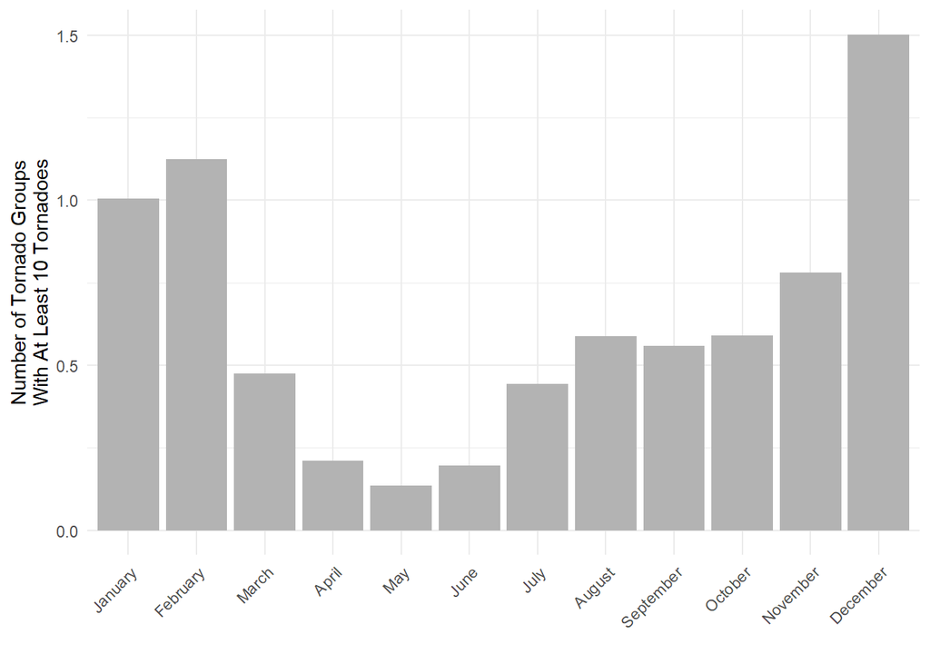

```r
ggplot(DLBSByMonth, aes(x = as.factor(Mo), y = avgDLBS)) +
  geom_bar(stat = "identity", fill = "gray70") +
  scale_x_discrete(labels = month.name) +
  scale_y_continuous(limits = c(0, NA)) +
  ylab("Number of Tornado Groups\nWith At Least 10 Tornadoes") + xlab("") +
  theme_minimal() +
  theme(axis.text.x = element_text(angle = 45, hjust = 1))
```

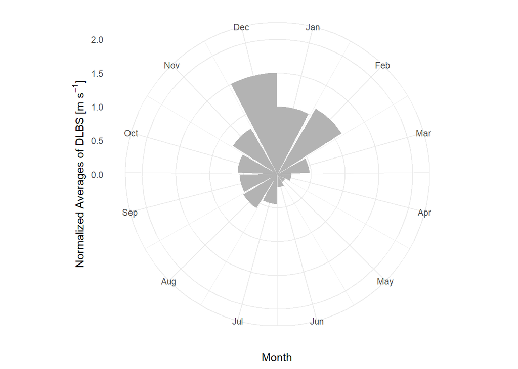

```r
( p0 <- ggplot(DLBSByMonth, aes(x = Mo, y = avgDLBS)) +
  geom_bar(stat = "identity", fill = "gray70") +
 scale_x_continuous(breaks = seq(1, 12, 1), labels = month.abb) +
  scale_y_continuous(limits = c(0, 2)) +
  coord_polar(start =0) +
  labs(x = "Month", y = expression(paste("Normalized Averages of DLBS [m ", s^-1, "]"))) +
  #ggtitle("a") +
  theme_minimal() )
```

Diurnal Trend:

```r
DLBSByHour <- BigDays.sfdfT %>%
  group_by(Hour_UTC) %>%
  summarize(nC = n(),
            avgDLBS = mean(maxBS_deep))
```

[output not shown]

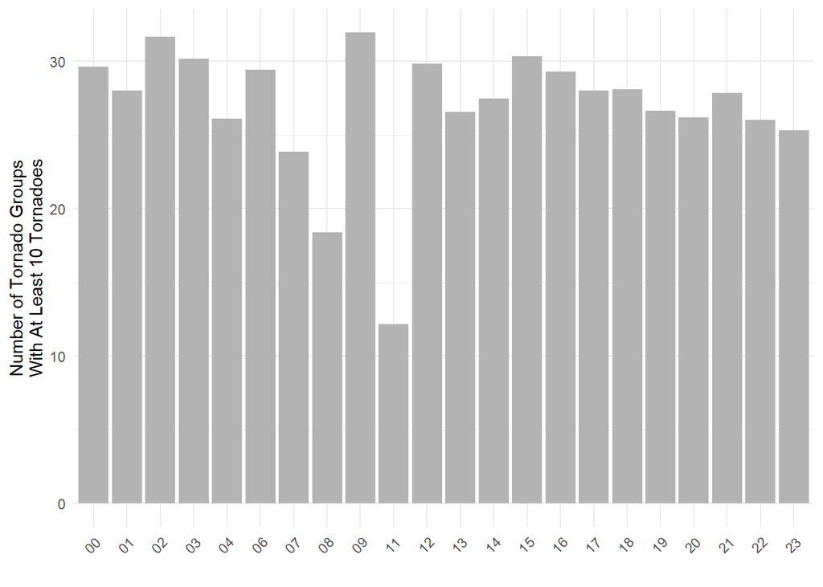

```r
ggplot(DLBSByHour, aes(x = as.factor(Hour_UTC), y = avgDLBS)) +
  geom_bar(stat = "identity", fill = "gray70") +
  #scale_x_discrete(labels = month.name) +
  scale_y_continuous(limits = c(0, NA)) +
  ylab("Number of Tornado Groups\nWith At Least 10 Tornadoes") + xlab("") +
  theme_minimal() +
  theme(axis.text.x = element_text(angle = 45, hjust = 1))
```

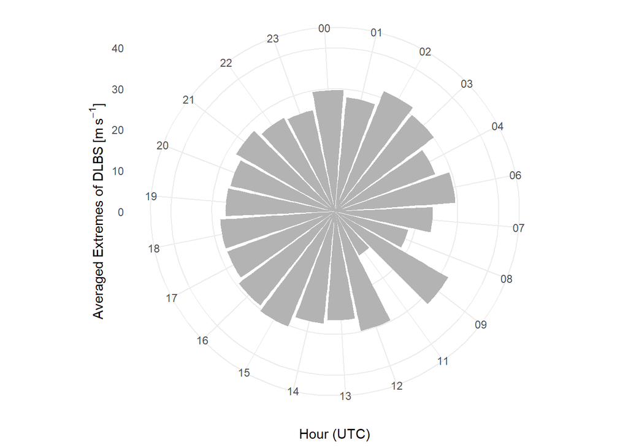

```r
( p1 <- ggplot(DLBSByHour, aes(x = as.factor(Hour_UTC), y = avgDLBS)) +
  geom_bar(stat = "identity", fill = "gray70") +
  #scale_x_discrete(breaks = seq(0, 24, 0.5)) +
  scale_y_continuous(limits = c(0, 40)) +
  coord_polar(start =-0.2) +
  labs(x = "Hour (UTC)", y = expression(paste("Averaged Extremes of DLBS [m ", s^-1, "]"))) +
  theme_minimal() )
```

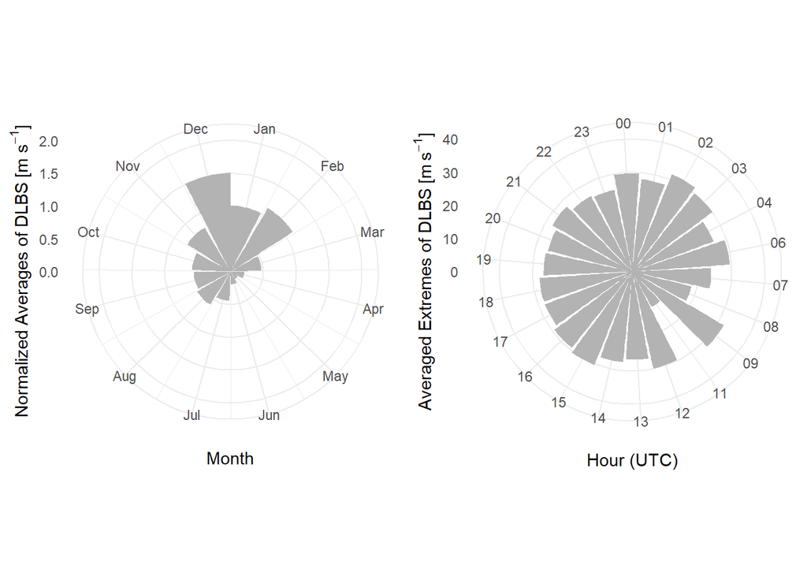

```r
ggarrange(p0, p1)
```

Annual Trend:

```r
DLBSByYear <- BigDays.sfdfT %>%
  group_by(Year) %>%
  summarize(avgDLBS = mean(maxBS_deep))
```

[output not shown]

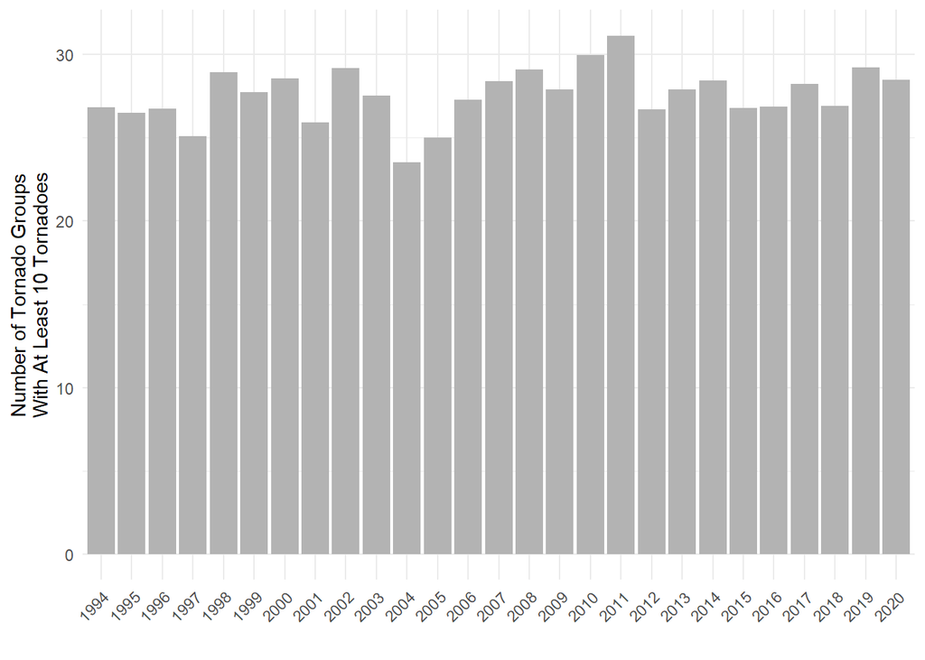

```r
ggplot(DLBSByYear, aes(x = as.factor(Year), y = avgDLBS)) +
  geom_bar(stat = "identity", fill = "gray70") +
  #scale_x_discrete(labels = month.name) +
  scale_y_continuous(limits = c(0, NA)) +
  ylab("Number of Tornado Groups\nWith At Least 10 Tornadoes") + xlab("") +
  theme_minimal() +
  theme(axis.text.x = element_text(angle = 45, hjust = 1))
```

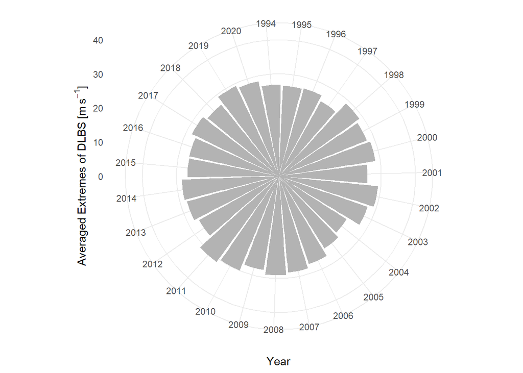

```r
( px <- ggplot(DLBSByYear, aes(x = as.factor(Year), y = avgDLBS)) +
  geom_bar(stat = "identity", fill = "gray70") +
  #scale_x_discrete(breaks = seq(0, 24, 0.5)) +
  scale_y_continuous(limits = c(0, 40)) +
  coord_polar(start =-0.2) +
  labs(x = "Year", y = expression(paste("Averaged Extremes of DLBS [m ", s^-1, "]"))) +
  theme_minimal() )
```

Models:

```r
DLBS_m2 <- lmer(maxBS_deep ~ SSTgradient_15day + avg_Nino3415day + NAO_15day + PNA_15day +  MJO_15day + Lat + Lon + (1|Month), data = BigDays.sfdfT)
summary(DLBS_m2)
```

```
## Linear mixed model fit by REML ['lmerMod']
## Formula: maxBS_deep ~ SSTgradient_15day + avg_Nino3415day + NAO_15day +
##     PNA_15day + MJO_15day + Lat + Lon + (1 | Month)
##    Data: BigDays.sfdfT
##
## REML criterion at convergence: 5360.5
##
## Scaled residuals:
##     Min      1Q  Median      3Q     Max
## -3.8130 -0.6240  0.0004  0.6843  3.0909
##
## Random effects:
##  Groups   Name        Variance Std.Dev.
##  Month    (Intercept) 14.85    3.853
##  Residual             35.58    5.965
## Number of obs: 830, groups:  Month, 12
##
## Fixed effects:
##                   Estimate Std. Error t value
## (Intercept)        1.33189   11.06070   0.120
## SSTgradient_15day  0.96969    0.21730   4.462
## avg_Nino3415day    0.34175    0.30915   1.105
## NAO_15day         -0.87091    0.27124  -3.211
## PNA_15day         -0.59464    0.20650  -2.880
## MJO_15day         -0.18135    0.40578  -0.447
## Lat                0.34834    0.06033   5.774
## Lon                0.15015    0.03452   4.350
##
## Correlation of Fixed Effects:
##             (Intr) SST_15 a_N341 NAO_15 PNA_15 MJO_15 Lat
## SSTgrdnt_15 -0.631
## avg_Nn3415d -0.876  0.352
## NAO_15day   -0.056  0.063  0.046
## PNA_15day    0.128  0.064 -0.211  0.115
## MJO_15day    0.041 -0.009 -0.096  0.046  0.001
## Lat         -0.243  0.113  0.062 -0.059  0.126 -0.019
## Lon          0.174  0.079  0.064 -0.030  0.044  0.027  0.149
```